# Las emisiones de CO<sub>2</sub>: una de las causas que ocasiona el cambio climático propiciado por la actividad humana

Alba Colado Suarez

11/3/2022

# 1. Problema ambiental

Entre las causas del cambio del clima que estamos experimentando actualmente, podriamos destacar las emisiones de CO<sub>2</sub> como un factor relevante, encontrandose estas dentro de los conocidos gases de efecto invernadero. La actividad humana esta haciendo que estos gases tengan un efecto sobre la atmosfera, aumentando su capacidad en la conservacion del calor, dando lugar a este fenomeno. Para evaluar si realmente la actividad humana es un factor a considerar culpable del aumento de temperaturas y del nivel del mar o del deshielo, se han tomado como referencia datos de las emisiones en todo el territorio peninsular, Ceuta y Melilla asi como los archipielagos de las Islas Baleares y las Islas Canarias. Tambien se han recopilado datos de empresas y habitantes en cada comunidad, intentando llegar a la conclusion de que estos dos son factores que propician el cambio climatico. De acuerdo con lo que expone la Comisión Europea, la hipótesis de las empresas debería cumplirse, ya que los niveles en el anyo 2020 alcanzaban unos valores que practicamente doblaban los registrados antes de la industrializacion (aproximadamente en 1750). Aclaracion: durante todo el trabajo las cifras de las emisiones son expresadas en terminos de CO<sub>2</sub> equivalente (CO<sub>2</sub>-eq)

```r
co2 <- read_delim(here("03-Clean", "Emisiones_por_CCAA.csv"))
empresas <- read_delim(here("03-Clean", "Empresas_por_comunidad_autonoma.csv"))
pobl <- read_delim(here("03-Clean", "Poblacion_2020.csv"))

View(co2)
View(empresas)
View(pobl)
```

# 2. Objetivos

- Demostrar que la actividad humana tiene impacto sobre las emisiones de CO<sub>2</sub>
- Analizar si el numero de empresas influye en la cantidad de emisiones que se registran por comunidad
- Analizar si hay relacion entre el numero de habitantes y las emisiones recogidas por comunidad

```r
co2_data <- co2 %>%
  pivot_longer(
    cols = "2005":"2019",
    names_to = "Anyo",
    values_to = "Valor"
  )

glimpse(co2_data)
```

```
## Rows: 285
## Columns: 3
## $ Comunidad <chr> "Andalucia", "Andalucia", "Andalucia", "Andalucia", "Andaluc~
## $ Anyo      <chr> "2005", "2006", "2007", "2008", "2009", "2010", "2011", "201~
## $ Valor     <dbl> 67365, 67036, 69801, 60820, 57927, 55833, 55143, 53704, 5016~
```

```r
nrow(co2)
```

```
## [1] 19
```

```r
nrow(co2_data)
```

```
## [1] 285
```

```r
view(co2_data)

empresas_data <- empresas %>%
  pivot_longer(
    cols = "2020":"2021",
    names_to = "Anyo",
    values_to = "Empresas"
  )

glimpse(empresas_data)
```

```
## Rows: 38
## Columns: 3
## $ Comunidad <chr> "Cataluna", "Cataluna", "Madrid", "Madrid", "Andalucia", "An~
## $ Anyo      <chr> "2020", "2021", "2020", "2021", "2020", "2021", "2020", "202~
## $ Empresas  <dbl> 629876, 622967, 552027, 547040, 531045, 531160, 370645, 3680~
```

```r
nrow(empresas)
```

```
## [1] 19
```

```r
nrow(empresas_data)
```

```
## [1] 38
```

```r
view(empresas_data)
```

# 3. Datos

# 4. Metodologia empleada

- Elaboracion de hipotesis en base a un problema ambiental
- Descargar los datos referentes a las hipotesis
- Tratamiento de los datos
- Creacion de figuras en base a las hipotesis
- Resultados y conclusiones

# 5. Procedimiento

## Tabla con la media de los valores

```r
co2_all <- co2_data%>%
  group_by(Comunidad) %>%
  summarise(
    co2mean = mean(Valor)
    )

empresas_all <- empresas_data%>%
  group_by(Comunidad) %>%
  summarise(
    empresasmean = mean(Empresas)
  )
```

```r
tabla_kk <- merge(x = co2_all, y = empresas_all)
tabla_conanyo <- merge(x = tabla_kk, y = pobl)
tabla_final <- tabla_conanyo %>%
  dplyr::select(Comunidad, co2mean, empresasmean, Hab)
```

Para hacer la tabla final que incluye las variables: Comunidad Autonoma, Niveles de CO<sub>2</sub>, Numero de habitantes y Numero de empresas, hubo que hacer una seleccion de datos para tener las tres tablas con el mismo numero de filas En el caso del Numero de habitantes no hizo falta hacer ninguna operacion, ya que solo habia un anyo En la tabla del CO<sub>2</sub> para cada Comunidad Autonoma se hizo una media de los valores de CO<sub>2</sub> disponibles entre el 2005 y el 2019 En la tabla de Numero de empresas tambien se hizo una media entre los valores de 2020 y 2021 para cada Comunidad Asi, en cada tabla tendriamos el mismo formato: tres columnas y 19 filas

## Grafica para evaluar los niveles de CO<sub>2</sub> desde 2005 hasta 2019

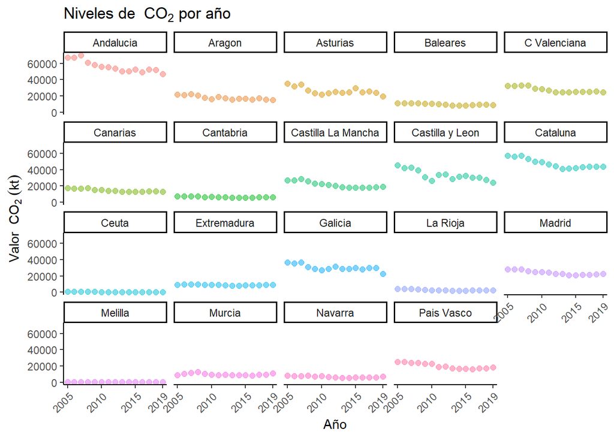

```r
co2_anyos_ca <- ggplot(data = co2_data, aes(x = Anyo, y = Valor))+
  geom_point(aes(color = Comunidad),
             size = 2,
             alpha = 0.5)+
  geom_smooth(aes(color = Comunidad,
                  method = "lm"))+
  ggtitle(expression(paste("Niveles de "~CO[2], " por año")))+
  labs(x = "Año",
       y = "Valor "~CO[2]~(kt),"")+
  theme_classic()+
  theme(legend.position = "none",
        axis.text.x = element_text(angle = 45,
                                   hjust = 1))+
  scale_x_discrete(breaks=c("2005", "2010", "2015", "2019"))


co2_anyos_ca+
  facet_wrap(.~ Comunidad)
```

```r
ggsave(
  plot = co2_anyos_ca+
  facet_wrap(.~ Comunidad),
  here("04-Figuras", "co2_anyos_ca.png"),
  width = 10, height = 8
)
```

En unas cuantas Comunidades autonomas se tiende a ver en el ultimo anyo registrado una tendencia decreciente de las emisiones de CO<sub>2</sub>, aunque no se dispongan de los datos de 2020 cabria pensar que la tendencia seguiria siendo decreciente, principalmente por el paron globalizado que hubo en este anyo debido a la crisis sanitaria del COVID-19

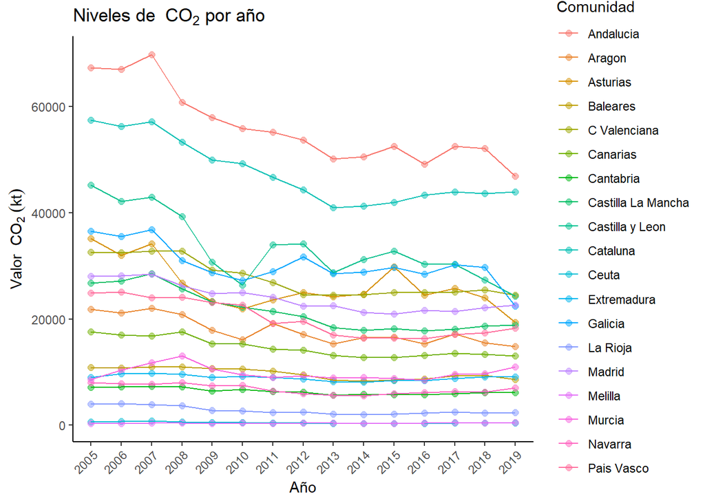

```r
co2_anyos <- ggplot(data = co2_data, aes(x = Anyo, y = Valor))+
  geom_point(aes(color = Comunidad,
                 group = Comunidad),
             size = 2,
             alpha = 0.5)+
  geom_line(aes(color = Comunidad,
                group = Comunidad))+
  labs(x = "Año",
       y = "Valor "~CO[2]~(kt),"")+
  ggtitle(expression(paste("Niveles de "~CO[2], " por año")))+
  theme_classic()+
  theme(legend.position = "right",
        axis.text.x = element_text(angle = 45,
                                   hjust = 1))

co2_anyos
```

```r
ggsave(
  plot = co2_anyos,
  here("04-Figuras", "co2_anyos.png"),
  width = 10, height = 8
)
```

## Grafica para observar que Comunidades Autonomas presentan mayores niveles de CO<sub>2</sub>

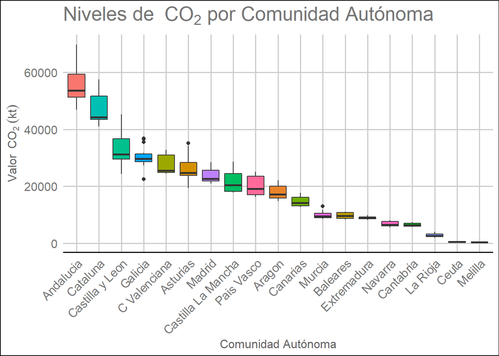

```r
comunidad_co2 <- ggplot(data = co2_data, aes(x = reorder(Comunidad, -Valor), y = Valor))+
  geom_boxplot(aes(fill = Comunidad))+
  theme_gdocs()+
  theme(legend.position = "none",
        axis.text.x = element_text(angle = 45,
                                   hjust = 1))+
  labs(x = "Comunidad Autónoma",
       y = "Valor "~CO[2]~(kt),"")+
  ggtitle(expression(paste("Niveles de "~CO[2], " por Comunidad Autónoma")))

comunidad_co2
```

```r
ggsave(
  plot = comunidad_co2,
  here("04-Figuras", "comunidad_co2.png"),
  width = 12, height = 8
)
```

Las comunidades con niveles de CO<sub>2</sub> mas elevados serian (respectivamente) Andalucia, Cataluna y Castilla y Leon

## Grafica para observar que Comunidades Autonomas presentan mayor numero de habitantes

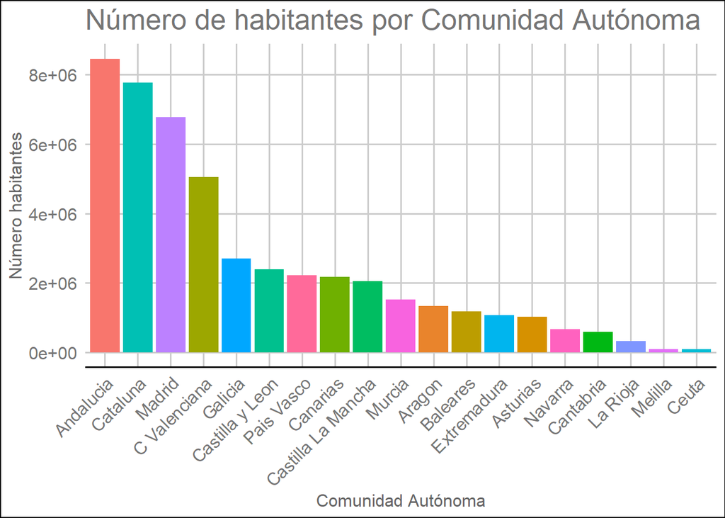

```r
hab_comunidad <- ggplot(data = pobl, aes(x = reorder(Comunidad, -Hab), y = Hab))+
  geom_bar(aes(fill = Comunidad),
           stat = "identity"
           )+
  theme_gdocs()+
  labs(x = "Comunidad Autónoma",
       y = "Número habitantes",
       title = "Número de habitantes por Comunidad Autónoma")+
  theme(legend.position = "none",
        axis.text.x = element_text(angle = 45,
                                   hjust = 1))

hab_comunidad
```

```r
ggsave(
  plot = hab_comunidad,
  here("04-Figuras", "hab_comunidad.png"),
  width = 12, height = 8
)
```

Las comunidades con mayor poblacion son Andalucia, Cataluna y Madrid

## Grafica para observar que Comunidades Autonomas presentan mayor numero de empresas

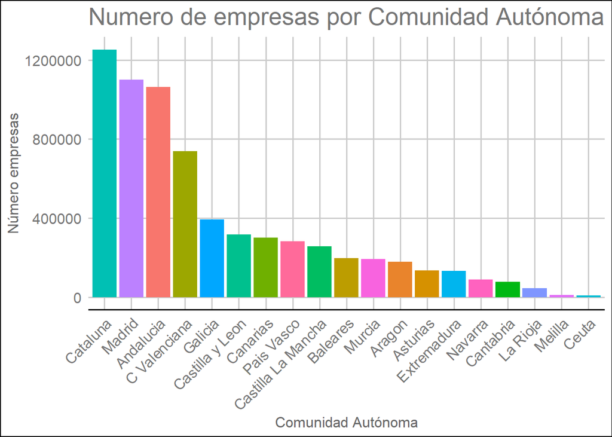

```r
comunidad_empresas <- ggplot(data = empresas_data, aes(x = reorder(Comunidad, -Empresas), y = Empresas))+
  geom_bar(aes(fill = Comunidad),
           stat = "identity",
           )+
  theme_gdocs()+
  labs(x = "Comunidad Autónoma",
       y = "Número empresas",
       title = "Numero de empresas por Comunidad Autónoma")+
  theme(legend.position = "none",
        axis.text.x = element_text(angle = 45,
                                   hjust = 1))

comunidad_empresas
```

```r
ggsave(
  plot = comunidad_empresas,
  here("04-Figuras", "comunidad_empresas.png"),
  width = 12, height = 8
)
```

Las comunidades con mayor numero de empresas se corresponden con Cataluna en primer lugar, seguido por Madrid y Andalucia

## Grafico para evaluar si los habitantes influyen en los niveles de CO<sub>2</sub>

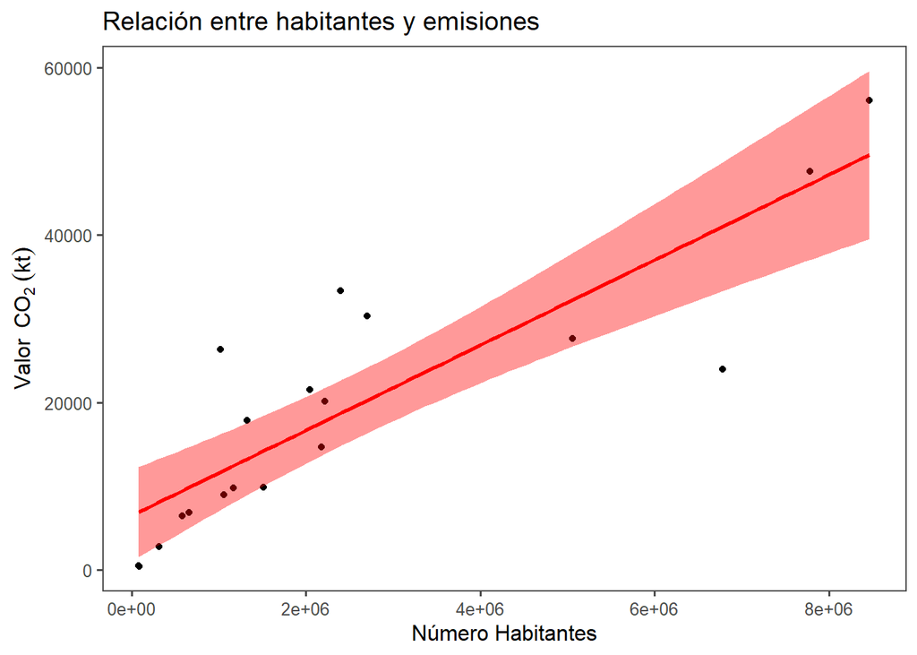

```r
lines_points <- lines+
  geom_point(colors = "saddlebrown", alpha = 0.5)

relacion_co2_hab <- ggplot(data = tabla_final, aes(x = Hab, y = co2mean))+
  geom_point()+
  labs(x = "Número Habitantes",
       y = "Valor "~CO[2]~(kt),"",
       title = "Relación entre habitantes y emisiones")+
  theme_few()+
  lines_points+
  geom_smooth(color = "Red",
              fill = "Red",
              method = "lm")

relacion_co2_hab
```

```r
ggsave(
  plot = relacion_co2_hab,
  here("04-Figuras", "relacion_co2_hab.png"),
  width = 10, height = 8
)
```

Podemos concluir que realmente las emisiones si estan afectadas por la cantidad de poblacion, ya que, como observamos en la grafica, a mayor numero de habitantes, los valores de CO<sub>2</sub> tambien son cada vez mas elevados

## Grafico para evaluar si las empresas influyen en los niveles de CO<sub>2</sub>

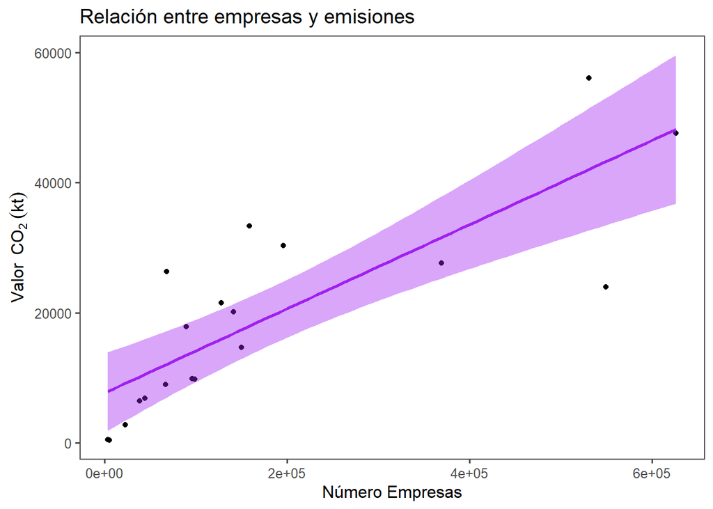

```r
lines_points <- lines+
  geom_point(colors = "saddlebrown", alpha = 0.5)

relacion_co2_empresas <- ggplot(data = tabla_final, aes(x = empresasmean, y = co2mean))+
  geom_point()+
  labs(x = "Número Empresas",
       y = "Valor "~CO[2]~(kt),"",
       title = "Relación entre empresas y emisiones")+
  theme_few()+
  lines_points+
  geom_smooth(color = "Purple",
              fill = "Purple",
              method = "lm")

relacion_co2_empresas
```

```r
ggsave(
  plot = relacion_co2_empresas,
  here("04-Figuras", "relacion_co2_empresas.png"),
  width = 10, height = 8
)
```

Al igual que el caso presentado en el grafico anterior, el numero de empresas tambien influye en la contaminacion ambiental. Observamos que un mayor numero de empresas registra valores mas elevados de CO<sub>2</sub>

## Grafico para evaluar si un mayor numero de habitantes implica que tambien haya un mayor numero de empresas

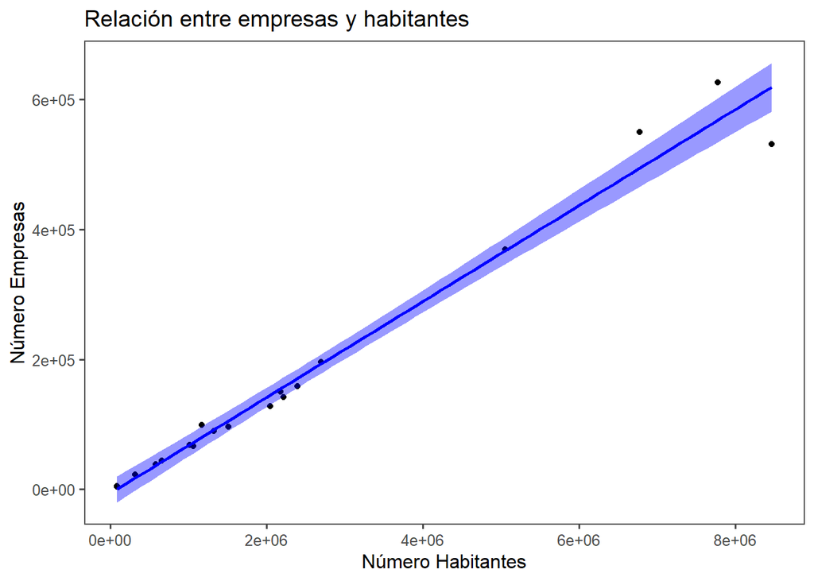

```r
lines_points <- lines+
  geom_point(colors = "saddlebrown", alpha = 0.5)

relacion_hab_empresas <- ggplot(data = tabla_final, aes(x = Hab, y = empresasmean))+
  geom_point()+
  labs(x = "Número Habitantes",
       y = "Número Empresas",
       title = "Relación entre empresas y habitantes")+
  theme_few()+
  lines_points+
  geom_smooth(color = "Blue",
              fill = "Blue",
              method = "lm")

relacion_hab_empresas
```

```r
ggsave(
  plot = relacion_hab_empresas,
  here("04-Figuras", "relacion_hab_empresas.png"),
  width = 10, height = 8
)
```

Cuantos mas habitantes tenga una comunidad, mayor numero de empresas tendra. Por lo que cabe pensar que las comunidades mas afectadas seran Catalunya, Madrid y Andalucia